# R Intermedio - Taller 1

N Montano

12 de noviembre de 2017

## Preeliminares

- Verificar que esté instalado RStudio y R (abrir RStudio), caso contrario: instalarlo
- Verificar que esté instalado el paquete tidyverse (en el panel de paquetes), caso contrario: instalarlo
- Abrir un script en R
- Guardarlo como: TALLER_01_APELLIDO_NOMBRE.r, por ejemplo, TALLER_01_MONTANO_NESTOR.r
- Al finalizar, enviarlo a rmontano@espol.edu.ec

## Data a usar

Se va a utilizar un data.frame que nos dará información sobre modelos de autos

```r
df_carros <- data.frame(
  MODELO= rownames(mtcars),
  TRANSMISION= ifelse(mtcars$am == 0, "automatica", "manual"),
  NUM_CILINDROS= mtcars$cyl,
  MPG= mtcars$mpg,
  CABALLOS_FUERZA= mtcars$hp
  )
```

La variable NUM_CILINDROS representa el número de cilindros, MPG representa las millas por galón, el resto el nombre indica su significado.

| MODELO | TRANSMISION | NUM_CILINDROS | MPG | CABALLOS_FUERZA |
| --- | --- | --- | --- | --- |
| Mazda RX4 | manual | 6 | 21.0 | 110 |
| Mazda RX4 Wag | manual | 6 | 21.0 | 110 |
| Datsun 710 | manual | 4 | 22.8 | 93 |
| Hornet 4 Drive | automatica | 6 | 21.4 | 110 |
| Hornet Sportabout | automatica | 8 | 18.7 | 175 |
| Valiant | automatica | 6 | 18.1 | 105 |
| Duster 360 | automatica | 8 | 14.3 | 245 |
| Merc 240D | automatica | 4 | 24.4 | 62 |
| Merc 230 | automatica | 4 | 22.8 | 95 |
| Merc 280 | automatica | 6 | 19.2 | 123 |

## Tema 1

Transforme el data.frame a tibble

## Tema 2

Usando el operador pipe `%>%` y los comandos de dplyr (tidyverse), genere un boxplot para la variable que represente los caballos de fuerza. El resultado debe ser similar a:

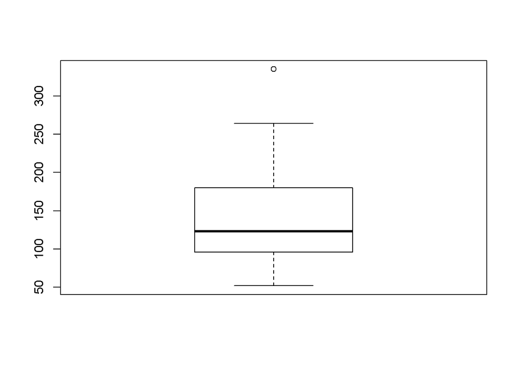

## Tema 3

Con los autos que tienen más de 4 cilindros (5 o más), calcule la media, mediana y cantidad de datos para las variables millas por galón y caballos de fuerza; todo esto usando los comandos de dplyr (tidyverse). El resultado debe ser parecido a:

| MPG_MEDIA | CABALLOS_FUERZA_MEDIA | MPG_MEDIANA | CABALLOS_FUERZA_MEDIANA | MPG_CANTIDAD | CABALLOS_FUERZA_CANTIDAD |
| --- | --- | --- | --- | --- | --- |
| 16.64762 | 180.2381 | 16.4 | 175 | 21 | 21 |

## Tema 4

Lo mismo que el tema 3, pero por tipo de transmisión y usando los comandos de dplyr (tidyverse),. El resultado debe ser parecido a:

| TRANSMISION | MPG_MEDIA | CABALLOS_FUERZA_MEDIA | MPG_MEDIANA | CABALLOS_FUERZA_MEDIANA | MPG_CANTIDAD | CABALLOS_FUERZA_CANTIDAD |
| --- | --- | --- | --- | --- | --- | --- |
| automatica | 16.06875 | 174.4375 | 15.95 | 177.5 | 16 | 16 |
| manual | 18.50000 | 198.8000 | 19.70 | 175.0 | 5 | 5 |

## Tema 5

Con el data.frame:

```r
set.seed(1)
venta <- data.frame(
  ALM= rep(LETTERS[1:6], each= 3),
  PERIODO= c('201701', '201702', '201703'),
  VTA= round(runif(n = 18, min = 0, max= 100), 0),
  PPTO= round(runif(n = 18, min = 0, max= 100), 0)
)
```

Calcular, usando los comandos de dplyr (tidyverse), el cumplimiento mensual, es decir, cree una nueva columna que sea equivalente a venta sobre presupuesto. El resultado debe ser

| ALM | PERIODO | VTA | PPTO | CUMP |
| --- | --- | --- | --- | --- |
| A | 201701 | 27 | 38 | 0.7105263 |
| A | 201702 | 37 | 78 | 0.4743590 |
| A | 201703 | 57 | 93 | 0.6129032 |
| B | 201701 | 91 | 21 | 4.3333333 |
| B | 201702 | 20 | 65 | 0.3076923 |
| B | 201703 | 90 | 13 | 6.9230769 |
| C | 201701 | 94 | 27 | 3.4814815 |
| C | 201702 | 66 | 39 | 1.6923077 |
| C | 201703 | 63 | 1 | 63.0000000 |
| D | 201701 | 6 | 38 | 0.1578947 |
| D | 201702 | 21 | 87 | 0.2413793 |
| D | 201703 | 18 | 34 | 0.5294118 |
| E | 201701 | 69 | 48 | 1.4375000 |
| E | 201702 | 38 | 60 | 0.6333333 |
| E | 201703 | 77 | 49 | 1.5714286 |
| F | 201701 | 50 | 19 | 2.6315789 |
| F | 201702 | 72 | 83 | 0.8674699 |
| F | 201703 | 99 | 67 | 1.4776119 |

## Tema 6

Con el data.frame:

```r
set.seed(1)
venta <- data.frame(
  ALM= rep(LETTERS[1:6], each= 3),
  PERIODO= c('201701', '201702', '201703'),
  VTA= round(runif(n = 18, min = 0, max= 100), 0),
  PPTO= round(runif(n = 18, min = 0, max= 100), 0)
)
```

Genere un reporte que le de la venta mensual del almacen, pero de forma horizontal. Así:

| ALM | 201701 | 201702 | 201703 |
| --- | --- | --- | --- |
| A | 27 | 37 | 57 |
| B | 91 | 20 | 90 |
| C | 94 | 66 | 63 |
| D | 6 | 21 | 18 |
| E | 69 | 38 | 77 |
| F | 50 | 72 | 99 |